# Growth of reported Covid-19 cases in Cote d’Ivoire

Raphael Volz (raphael.volz@hs-pforzheim.de)

DRAFT work in progress, last updated on 2020-04-27

# 1 Daily New Cases

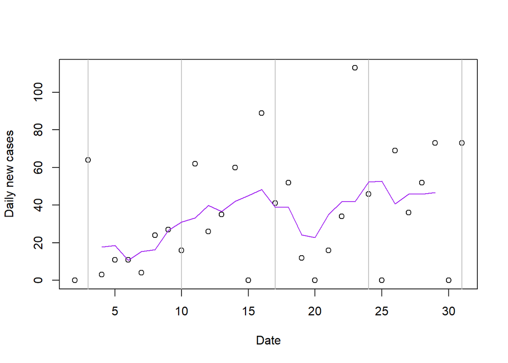

Figure 1.1: new cases and five day moving average.

## 1.1 Double sigmoidal model for daily new cases

Daily new cases peek after a certain time of growth that follows a sigmoidal function and then recedes to a lower level as the epidemic wave fades out and enters an endemic state. This behavior can be modelled with a double-sigmoid function $f_{base}$, that is obtained by the product of two sigmoidal functions [2].

$$f_{base}(t) = \frac{1}{ 1+e^{-\alpha_{i} * (t - t_{i})} } * \frac{1}{ 1+e^{-\alpha_{d} * (t - t_{d})} }$$

This function has a maximum $f_{max} = max(f_{base}(t_{max}))$ at $t_{max}$.

The model can obtain predictions related to an observed maximum of daily new cases $I_{max_{d}}$ and an endemic number of daily cases $I_{final_{d}}$ as an asymptote (that is ideally 0). Let $f_{d}(t)$ be a piecewise function that switches between the growth and decay phase at $t_{max}$, such that

$$\begin{aligned}f_{d}(t) = \left\{
\begin{array}{cc}
\frac{I_{max_{d}}}{f_{max}} * f_{base}(t) & \hspace{5mm} t \leq t_{max} \\
\frac{I_{max_{d}} - I_{final_{d} }}{f_{max}} * f_{base}(t) + I_{final_{d}} & \hspace{5mm} t > t_{max} \\
\end{array} \right.
\end{aligned}$$

where $t_{i}$ is the midpoint and $\alpha_{i}$ the slope of the increase of cases and $t_{d}$ is the midpoint and $\alpha_{d}$ is the slope of the decrease in cases. $I_{max_{d}}$ the peak of new cases and $I_{final_{d}}$ the asymptotic final value of new cases at the end of the infections wave. Figure 1.2 shows the current *double-sigmoidal model* that is fitted for the case time series of Cote d’Ivoire.

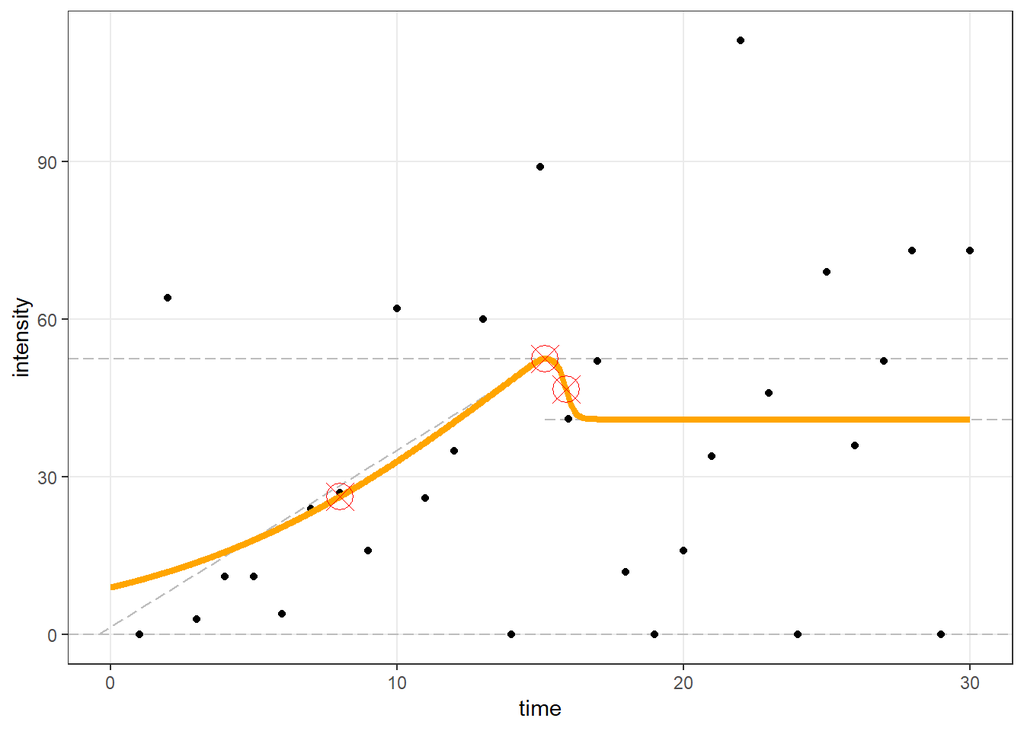

Figure 1.2: Double sigmoidal model fitted to new cases.

## 1.2 Week to week comparison of models

Since the model requires six parameters, it also requires more data points. Hence, it is only feasible to fit this model in later phases of the pandemic (ideally after the peak of daily infections occured) and the model is highly sensitive to new data, particularly with respect to finding the final asymptote $I_{final}$ as the following comparison of the model shows. Nevertheless the model renders interesting characteristica of the past developments.

| Model for Daily Increases | Current Estimates | Last Week Estimates | Delta (absolute) |
| --- | --- | --- | --- |
| $I_{max_{d}}$ Peak new cases | 53 | 47 | 5 |
| $I_{final_{d}}$ Endemic new cases | 41 | 0 | 41 |
| $\alpha_{i}$ Slope of increase phase | 0.16 | 0.13 | 0.03 |
| $t_{i}$ Midpoint of growth phase | 2020-04-03 (Day 8) | 2020-04-01 (Day 6) | 2 |
| $t_{max}$ Peak day | 2020-04-10 (Day 15) | 2020-04-18 (Day 23) | -8 |
| $\alpha_{d}$ Slope of decay phase | 6 | 7.5 | -1.5 |
| $t_{d}$ Midpoint of decrease phase | 2020-04-11 (Day 16) | 2020-04-18 (Day 23) | -7 |

In order to address the shortcoming of model instability under new data, we can attempt to fit a model on cumulative cases instead.

# 2 Cumulative cases

The cumulative total of COVID-19 cases in Cote d’Ivoire is the number of all COVID-19 cases known up to yesterday and **includes all patients already recovered from the infection**. This corresponds to the *Infected (I)* number in the standard epidemiological SIR model. Figure 2.1 shows the data points of the time series together with a Gompertz model for the cumulative cases (red line) as well as the cumulated double-sigmoidal model (orange line).

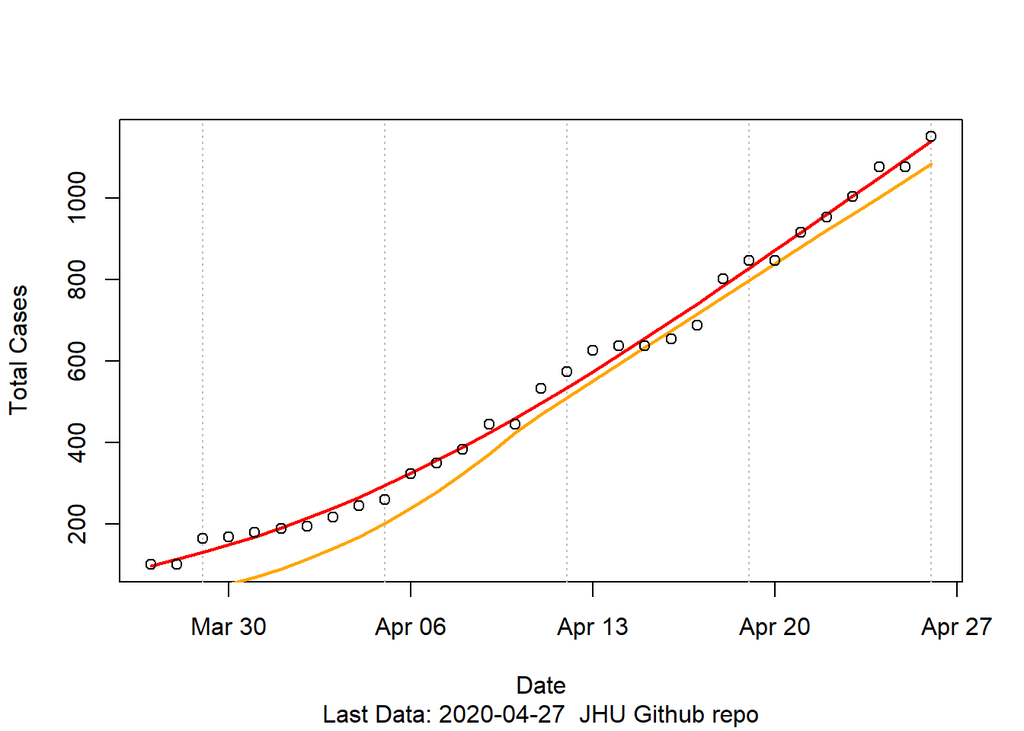

Figure 2.1: Cumulative cases with fitted models

## 2.1 Gompertz model for cumulative cases

The Gompertz model [3] is a sigmoid model that is often fitted to growth data, and often prefered over the standard logistic model (als called Verhulst model) due its asymetry. The Gompertz can be considered as a special case of the four parameter Richards model and is computationally easier to fit as it has one parameter less. The model is based on the cumulative distribution function $f_{c}(t)$, which is a three parameter logistic function:

$$f_{c}(t) = I_{max_{c}} * e^{ - \beta_{c} * e^{ - \alpha_{c} * t }}$$

Where the parameter $I_{max_{c}}$ is the estimated maximum number of cumulative cases (asymptote), $\beta_{c}$ inflects the curve along time, and $\alpha_{c}$ is the maximum absolute growth rate of cumulated cases.

This function is the integral of the probability density function (PDF) developed by Benjamin Gompertz in 1825 to model human mortality, hence his probability densitiy function (PDF) is the derivative of the CDF:

$$\frac{\partial f_{c}(t)}{\partial t} = I_{max_{c}} * \beta_{c} * \alpha_{c} * e^{ - \beta_{c} * e^{ - \alpha_{c} * t } - \alpha_{c} * t}$$

## 2.2 Week to week comparison of models

The Gompertz model change over time as new data is available. Obviously, we are interested whether the models are reliable and in particular show some convergence. When we compare the current model with the model calculated using the information that was available last week, we can again observe how the model parameters have changed.

[output not shown]

## 2.3 Parameter convergence of the Gompertz model

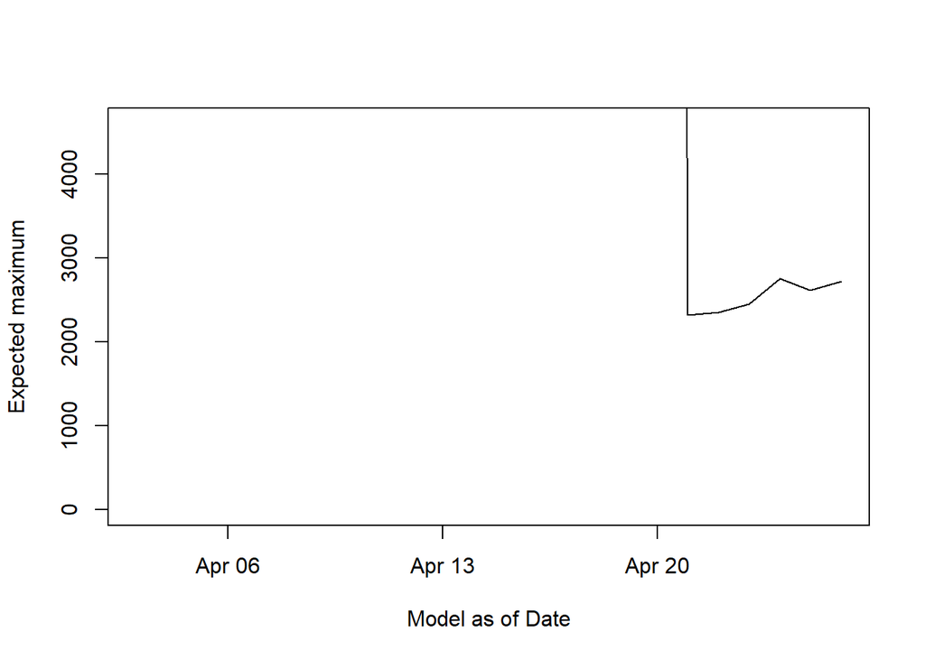

Figure 2.2: Parameter evolution of expected maximum (I_max_c)

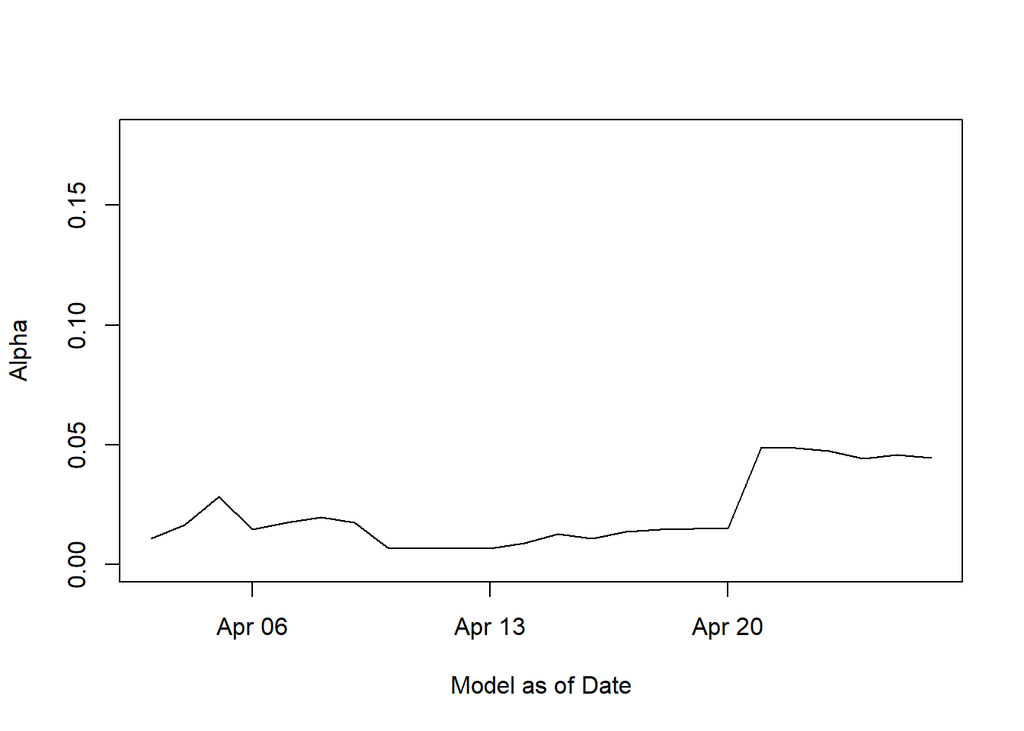

Figure 2.3: Parameter evolution of growth rate (alpha_c)

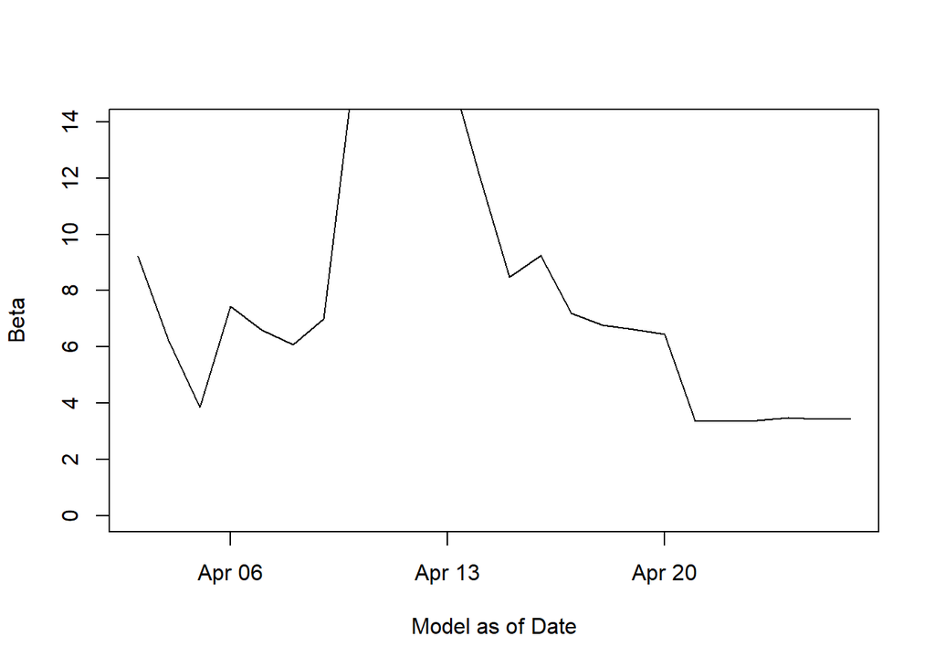

Figure 2.4: Parameter evolution of time shift (beta_c)

# 3 Projections

## 3.1 Methodology

Putting in future dates into the current model allows to project future cases. *Note:* The actual development can differ from model predictions, for example if social distancing norms change or methods in data collection are altered. If such changes happen, a model fitted to the past is no longer valid.

## 3.2 Nowcast

Yesterday 1150 COVID-19 cases were known in Cote d’Ivoire [1]. Figure 3.1 illustrates how past models (grey line) have predicted the last known number of cumulative COVID-19 cases (dashed black line).

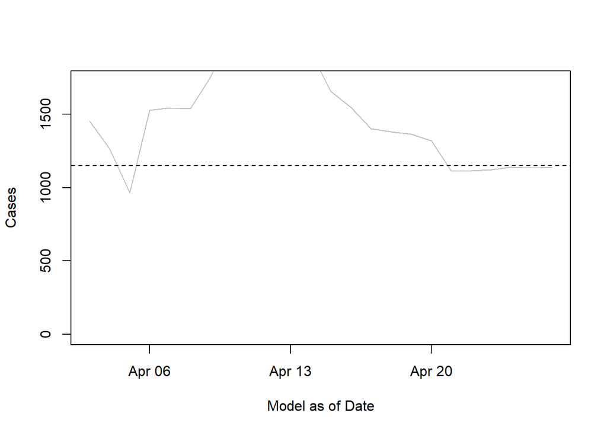

Figure 3.1: Nowcast of past models for yesterday

## 3.3 Forecast

Using the current model fitted to all available data we can estimate the future number of total COVID-19 cases in the next couple of days using either model or the ensembled mean prediction of both models.

Table 3.1: Projected COVID-19 Cases in Cote d’Ivoire

| Date | Model_Mean | Gompertz_Model | DSM_Model |
| --- | --- | --- | --- |
| 2020-04-27 | 1,187 | 1,183 | 1,191 |
| 2020-04-28 | 1,229 | 1,226 | 1,232 |
| 2020-04-29 | 1,271 | 1,270 | 1,273 |
| 2020-04-30 | 1,313 | 1,313 | 1,314 |
| 2020-05-01 | 1,355 | 1,355 | 1,355 |
| 2020-05-02 | 1,396 | 1,397 | 1,396 |
| 2020-05-03 | 1,437 | 1,438 | 1,437 |
| 2020-05-04 | 1,478 | 1,479 | 1,478 |

# 4 Discussion and outlook

As a next step the convergence of models could be investigated more closely to assess whether model divergence is an early indicator for a general change in infective behavior. Additional data about the population and population structure could be used to compare between countries, for example to assess the effectiveness of different public policies for controlling the disease.

# 5 References

1. Johns Hopkins University, *COVID-19 global case time series (csse_covid_19_time_series)*, online https://github.com/CSSEGISandData/COVID-19/blob/master/csse_covid_19_data/csse_covid_19_time_series/ (Last accessed 2020-04-27)
2. Mehmet Caglar, Ashley Teufel, Claus Wilke, *Sicegar: R package for sigmoidal and double-sigmoidal curve fitting* in PeerJ. 2018 Jan 16;6:e4251. doi: 10.7717/peerj.4251. eCollection 2018.
3. Benjamin Gompertz, *On the nature of the function expressive of the law of human mortality and a new mode of determining the value of life contingencies*. Philosophical Transactions of the Royal Society of London : Biological Sciences. 1825, 182:5 13-85.

# 6 Appendix

## 6.1 Cumulative (Gompertz) model history

| Date | # Cases | # Days | I_max | beta | alpha | RMSE (Train) | RMSE (Test) | Nowcast |
| --- | --- | --- | --- | --- | --- | --- | --- | --- |
| 2020-04-03 | 218 | 8 | 1,037,945 | 9.21 | 0.01 | 16 | 114 | 1,454 |
| 2020-04-04 | 245 | 9 | 52,998 | 6.24 | 0.02 | 15 | 62 | 1,266 |
| 2020-04-05 | 261 | 10 | 4,788 | 3.85 | 0.03 | 14 | 130 | 965 |
| 2020-04-06 | 323 | 11 | 168,118 | 7.43 | 0.01 | 15 | 156 | 1,526 |
| 2020-04-07 | 349 | 12 | 71,379 | 6.60 | 0.02 | 15 | 172 | 1,543 |
| 2020-04-08 | 384 | 13 | 41,299 | 6.08 | 0.02 | 15 | 177 | 1,535 |
| 2020-04-09 | 444 | 14 | 100,951 | 7.00 | 0.02 | 16 | 288 | 1,749 |
| 2020-04-10 | 444 | 15 | 999,988,696 | 16.13 | 0.01 | 16 | 421 | 2,044 |
| 2020-04-11 | 533 | 16 | 1,000,000,000 | 16.15 | 0.01 | 16 | 485 | 2,140 |
| 2020-04-12 | 574 | 17 | 1,000,000,000 | 16.15 | 0.01 | 15 | 504 | 2,143 |
| 2020-04-13 | 626 | 18 | 1,000,000,000 | 16.15 | 0.01 | 15 | 511 | 2,123 |
| 2020-04-14 | 638 | 19 | 18,982,220 | 12.16 | 0.01 | 18 | 421 | 1,919 |
| 2020-04-15 | 638 | 20 | 501,121 | 8.49 | 0.01 | 24 | 289 | 1,657 |
| 2020-04-16 | 654 | 21 | 1,162,916 | 9.25 | 0.01 | 31 | 228 | 1,546 |
| 2020-04-17 | 688 | 22 | 151,786 | 7.18 | 0.01 | 34 | 147 | 1,401 |
| 2020-04-18 | 801 | 23 | 101,767 | 6.79 | 0.01 | 33 | 143 | 1,381 |
| 2020-04-19 | 847 | 24 | 87,780 | 6.63 | 0.01 | 33 | 140 | 1,363 |
| 2020-04-20 | 847 | 25 | 75,785 | 6.45 | 0.01 | 35 | 114 | 1,318 |
| 2020-04-21 | 916 | 26 | 2,321 | 3.36 | 0.05 | 26 | 28 | 1,112 |
| 2020-04-22 | 952 | 27 | 2,353 | 3.37 | 0.05 | 25 | 29 | 1,114 |
| 2020-04-23 | 1,004 | 28 | 2,449 | 3.40 | 0.05 | 25 | 28 | 1,122 |
| 2020-04-24 | 1,077 | 29 | 2,751 | 3.48 | 0.04 | 25 | 15 | 1,141 |
| 2020-04-25 | 1,077 | 30 | 2,610 | 3.44 | 0.05 | 25 | 17 | 1,133 |
| 2020-04-26 | 1,150 | 31 | 2,716 | 3.47 | 0.04 | 24 | NaN | 1,139 |